# Mass spectrometry and proteomics

# 6 Quantitative data

Quantiative data is stored a objects of class `MSnSet`, which can be

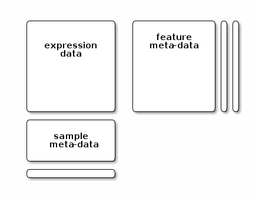

Figure 1: The MSnSet structure

1. Created from an `MSnExp` object with the `quantify` function.

```r
data(itraqdata)
itraqdata
```

```
## MSn experiment data ("MSnExp")
## Object size in memory: 1.9 Mb
## - - - Spectra data - - -
##  MS level(s): 2
##  Number of spectra: 55
##  MSn retention times: 19:9 - 50:18 minutes
## - - - Processing information - - -
## Data loaded: Wed May 11 18:54:39 2011
## Updated from version 0.3.0 to 0.3.1 [Fri Jul  8 20:23:25 2016]
##  MSnbase version: 1.1.22
## - - - Meta data  - - -
## phenoData
##   rowNames: 1
##   varLabels: sampleNames sampleNumbers
##   varMetadata: labelDescription
## Loaded from:
##   dummyiTRAQ.mzXML
## protocolData: none
## featureData
##   featureNames: X1 X10 ... X9 (55 total)
##   fvarLabels: spectrum ProteinAccession ProteinDescription
##     PeptideSequence
##   fvarMetadata: labelDescription
## experimentData: use 'experimentData(object)'
```

```r
msnset <- quantify(itraqdata, method = "trap", reporters = iTRAQ4)
msnset
```

```
## MSnSet (storageMode: lockedEnvironment)
## assayData: 55 features, 4 samples
##   element names: exprs
## protocolData: none
## phenoData
##   sampleNames: iTRAQ4.114 iTRAQ4.115 iTRAQ4.116 iTRAQ4.117
##   varLabels: mz reporters
##   varMetadata: labelDescription
## featureData
##   featureNames: X1 X10 ... X9 (55 total)
##   fvarLabels: spectrum ProteinAccession ... collision.energy (15
##     total)
##   fvarMetadata: labelDescription
## experimentData: use 'experimentData(object)'
## Annotation: No annotation
## - - - Processing information - - -
## Data loaded: Wed May 11 18:54:39 2011
## Updated from version 0.3.0 to 0.3.1 [Fri Jul  8 20:23:25 2016]
## iTRAQ4 quantification by trapezoidation: Fri Jul  5 09:26:02 2019
##  MSnbase version: 1.1.22
```

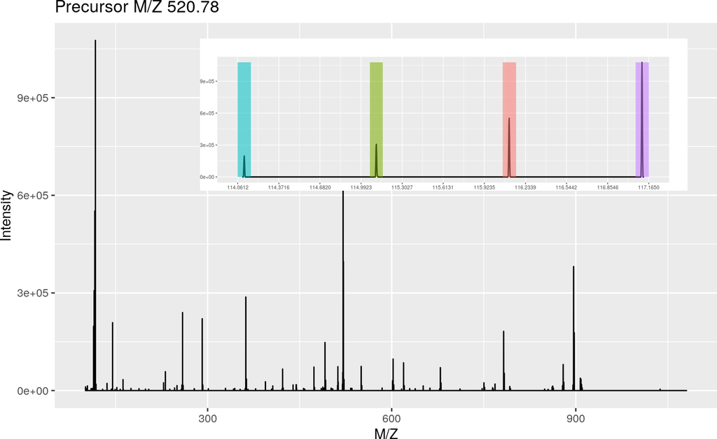

Figure 2: Raw data and quantiative results

```r
plot(itraqdata[[1]], reporters = iTRAQ4, full = TRUE)
```

```r
exprs(msnset)[1, ]
```

```
## iTRAQ4.114 iTRAQ4.115 iTRAQ4.116 iTRAQ4.117
##   1347.616   2247.310   3927.693   7661.146
```

```r
fData(msnset)[1, ]
```

```
##    spectrum ProteinAccession   ProteinDescription PeptideSequence fileIdx
## X1        1              BSA bovine serum albumin          NYQEAK       1
##    retention.time precursor.mz precursor.intensity charge peaks.count
## X1        1149.31     520.7833             3449020      2        1922
##         tic ionCount ms.level acquisition.number collision.energy
## X1 26413754 26413754        2                  2               40
```

2. Created from a spreadsheet produced by a third party software using the `readMSnSet2` function.

Before reading the spreadsheet, we need to identify which columns contain quantitation data (that will be put into the `exprs` slot) and the feature data (that will be put into the `fData` slot).

**Download** the data [here](https://raw.githubusercontent.com/lgatto/bioc-ms-prot/master/data/cptac_peptides.txt).

```r
f <- "./data/cptac_peptides.txt"
getEcols(f, split = "\t")
```

```
##  [1] "Sequence"                 "N-term cleavage window"
##  [3] "C-term cleavage window"   "Amino acid before"
##  [5] "First amino acid"         "Second amino acid"
##  [7] "Second last amino acid"   "Last amino acid"
##  [9] "Amino acid after"         "A Count"
## [11] "R Count"                  "N Count"
## [13] "D Count"                  "C Count"
## [15] "Q Count"                  "E Count"
## [17] "G Count"                  "H Count"
## [19] "I Count"                  "L Count"
## [21] "K Count"                  "M Count"
## [23] "F Count"                  "P Count"
## [25] "S Count"                  "T Count"
## [27] "W Count"                  "Y Count"
## [29] "V Count"                  "U Count"
```

[output cut: 21 more lines]

```r
e <- grepEcols(f, "Intensity ", split = "\t") ## careful at the space!
(cptac <- readMSnSet2(f, ecol = e,
                      fnames = "Sequence",
                      sep = "\t"))
```

```
## MSnSet (storageMode: lockedEnvironment)
## assayData: 11466 features, 6 samples
##   element names: exprs
## protocolData: none
## phenoData: none
## featureData
##   featureNames: AAAAGAGGAGDSGDAVTK AAAALAGGK ... YYTVFDRDNNRVGFAEAAR
##     (11466 total)
##   fvarLabels: Sequence N.term.cleavage.window ... MS.MS.Count (65
##     total)
##   fvarMetadata: labelDescription
## experimentData: use 'experimentData(object)'
## Annotation:
## - - - Processing information - - -
##  MSnbase version: 2.10.1
```

We can access the expression data with `exprs` and the feature meta-data with `fData`.

For the sake of simplicity, we can clean up the feature variables and only keep those of interest. It is possible to do this interactively with

```r
cptac <- selectFeatureData(cptac)
```

or by setting the feature variables of interest.

```r
cptac <- selectFeatureData(cptac,
                           fcol = c("Proteins",
                                    "Potential.contaminant",
                                    "Reverse",
                                    "Sequence"))
```

Let’s also add sample annotations:

```r
cptac$group <- rep(c("6A", "6B"), each = 3)
cptac$sample <- rep(7:9, 2)
sampleNames(cptac) <- sub("Intensity.", "", sampleNames(cptac))
pData(cptac)
```

```
##      group sample
## 6A_7    6A      7
## 6A_8    6A      8
## 6A_9    6A      9
## 6B_7    6B      7
## 6B_8    6B      8
## 6B_9    6B      9
```

# 7 Data processing

## 7.1 Filtering out contaminants

```r
table(sel_conts <- fData(cptac)$Potential.contaminant != "+")
```

```
##
## FALSE  TRUE
##    81 11385
```

```r
table(sel_rev <- fData(cptac)$Reverse != "+")
```

```
##
## FALSE  TRUE
##    30 11436
```

```r
(cptac <- cptac[sel_conts & sel_rev, ])
```

```
## MSnSet (storageMode: lockedEnvironment)
## assayData: 11357 features, 6 samples
##   element names: exprs
## protocolData: none
## phenoData
##   sampleNames: 6A_7 6A_8 ... 6B_9 (6 total)
##   varLabels: group sample
##   varMetadata: labelDescription
## featureData
##   featureNames: AAAAGAGGAGDSGDAVTK AAAALAGGK ... YYTVFDRDNNRVGFAEAAR
##     (11357 total)
##   fvarLabels: Proteins Potential.contaminant Reverse Sequence
##   fvarMetadata: labelDescription
## experimentData: use 'experimentData(object)'
## Annotation:
## - - - Processing information - - -
## Subset [11466,6][11357,6] Fri Jul  5 09:26:04 2019
##  MSnbase version: 2.10.1
```

Note how the filtering has been recorded in the object’s processing log.

## 7.2 Notes on missing values

Unfortunately, some software uses 0 irrespecitve whether the data has intensity zero and when the data haven’t been observer. Below we fix this.

```r
exprs(cptac)[exprs(cptac) == 0] <- NA
table(is.na(exprs(cptac)))
```

```
##
## FALSE  TRUE
## 37533 30609
```

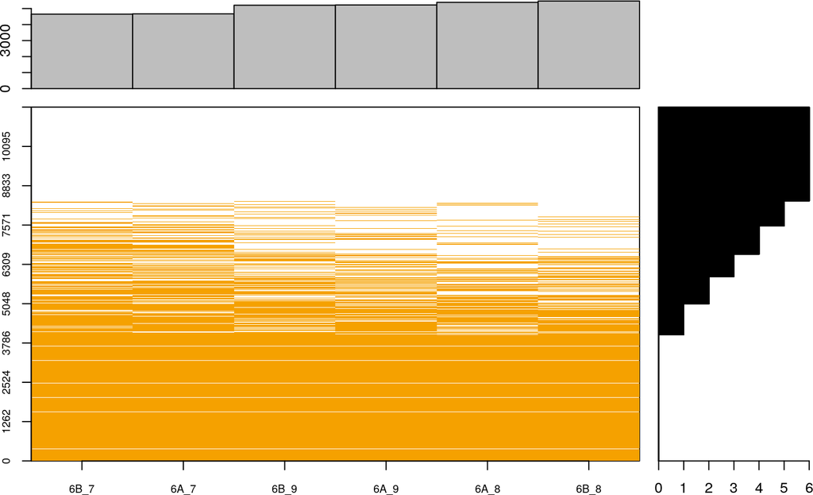

Figure 3: Overview of missing data

```r
napac <- cptac
exprs(napac)[!is.na(exprs(napac))] <- 1
naplot(napac)
```

```r
fData(cptac)$nNA <- apply(exprs(cptac), 1, function(x) sum(is.na(x)))
table(fData(cptac)$nNA)
```

```
##
##    0    1    2    3    4    5    6
## 4051  989  879  715  912  797 3014
```

(Note that some peptides aren’t seen at all because these 6 samples are a subset of a larger dataset, and these features are present in the other acquisitions.)

From here on, one could **filter** data with missing values, which however sacrifices a lot of data.

```r
(cptac <- filterNA(cptac))
```

```
## MSnSet (storageMode: lockedEnvironment)
## assayData: 4051 features, 6 samples
##   element names: exprs
## protocolData: none
## phenoData
##   sampleNames: 6A_7 6A_8 ... 6B_9 (6 total)
##   varLabels: group sample
##   varMetadata: labelDescription
## featureData
##   featureNames: AAAALAGGK AAAALAGGKK ... YYSISSSSLSEK (4051 total)
##   fvarLabels: Proteins Potential.contaminant ... nNA (5 total)
##   fvarMetadata: labelDescription
## experimentData: use 'experimentData(object)'
## Annotation:
## - - - Processing information - - -
## Subset [11466,6][11357,6] Fri Jul  5 09:26:04 2019
## Subset [11357,6][4051,6] Fri Jul  5 09:26:05 2019
## Removed features with more than 0 NAs: Fri Jul  5 09:26:05 2019
## Dropped featureData's levels Fri Jul  5 09:26:05 2019
##  MSnbase version: 2.10.1
```

Perform **imputation**, considering the underlying nature of missingness, i.e missing not at random (left-censored) or at random.

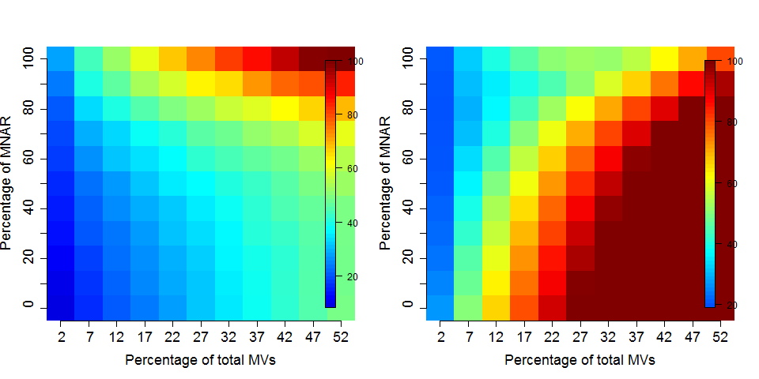

Root-mean-square error (RMSE) observations standard deviation ratio (RSR), KNN and MinDet imputation. Lower (blue) is better.

See Lazar *et al.* [Accounting for the Multiple Natures of Missing Values in Label-Free Quantitative Proteomics Data Sets to Compare Imputation Strategies](http://dx.doi.org/10.1021/acs.jproteome.5b00981).

The best solution is arguably to handle missing values at **the statistical test level** (see later).

## 7.3 Log transformation

```r
(cptac <- log(cptac, base = 2))
```

```
## MSnSet (storageMode: lockedEnvironment)
## assayData: 4051 features, 6 samples
##   element names: exprs
## protocolData: none
## phenoData
##   sampleNames: 6A_7 6A_8 ... 6B_9 (6 total)
##   varLabels: group sample
##   varMetadata: labelDescription
## featureData
##   featureNames: AAAALAGGK AAAALAGGKK ... YYSISSSSLSEK (4051 total)
##   fvarLabels: Proteins Potential.contaminant ... nNA (5 total)
##   fvarMetadata: labelDescription
## experimentData: use 'experimentData(object)'
## Annotation:
## - - - Processing information - - -
## Subset [11466,6][11357,6] Fri Jul  5 09:26:04 2019
## Subset [11357,6][4051,6] Fri Jul  5 09:26:05 2019
## Removed features with more than 0 NAs: Fri Jul  5 09:26:05 2019
## Dropped featureData's levels Fri Jul  5 09:26:05 2019
## Log transformed (base 2) Fri Jul  5 09:26:05 2019
##  MSnbase version: 2.10.1
```

## 7.4 Normalisation

Normalisation is handled by the `normalise` (or `normalize`) function.

```r
(cptac <- normalise(cptac, method = "quantiles"))
```

```
## MSnSet (storageMode: lockedEnvironment)
## assayData: 4051 features, 6 samples
##   element names: exprs
## protocolData: none
## phenoData
##   sampleNames: 6A_7 6A_8 ... 6B_9 (6 total)
##   varLabels: group sample
##   varMetadata: labelDescription
## featureData
##   featureNames: AAAALAGGK AAAALAGGKK ... YYSISSSSLSEK (4051 total)
##   fvarLabels: Proteins Potential.contaminant ... nNA (5 total)
##   fvarMetadata: labelDescription
## experimentData: use 'experimentData(object)'
## Annotation:
## - - - Processing information - - -
## Subset [11466,6][11357,6] Fri Jul  5 09:26:04 2019
## Subset [11357,6][4051,6] Fri Jul  5 09:26:05 2019
## Removed features with more than 0 NAs: Fri Jul  5 09:26:05 2019
## Dropped featureData's levels Fri Jul  5 09:26:05 2019
## Log transformed (base 2) Fri Jul  5 09:26:05 2019
## Normalised (quantiles): Fri Jul  5 09:26:05 2019
##  MSnbase version: 2.10.1
```

## 7.5 Summarisation

So far we have quantitation values at the peptide level, while the level of interest are proteins. We can take all peptides that are associated to a protein (or protein group), as defined by the `Proteins` feature variable and aggregate them using a preferred operation.

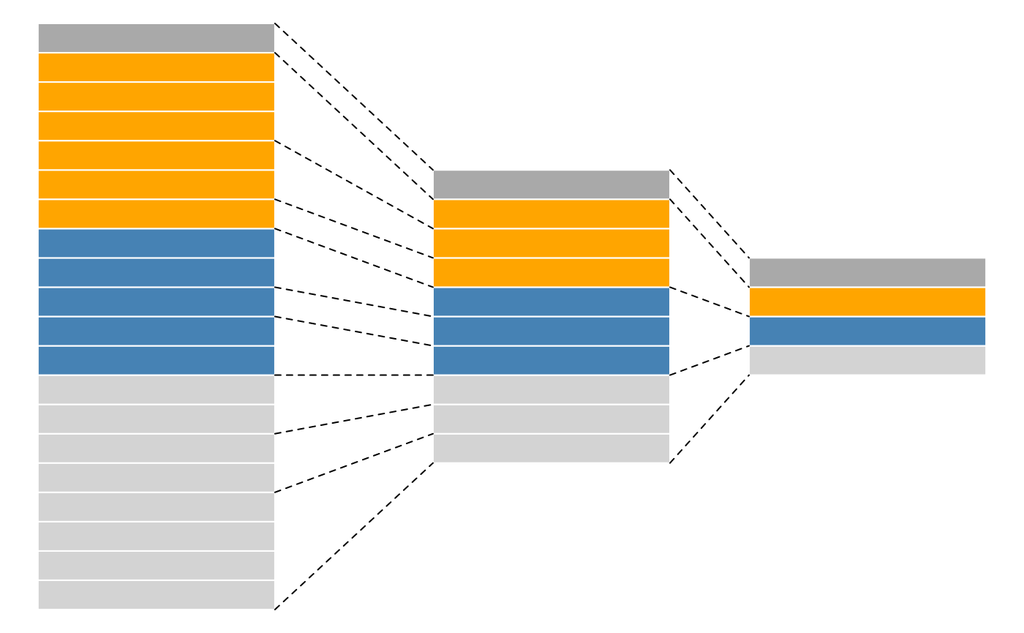

Figure 4: Aggregation between different levels

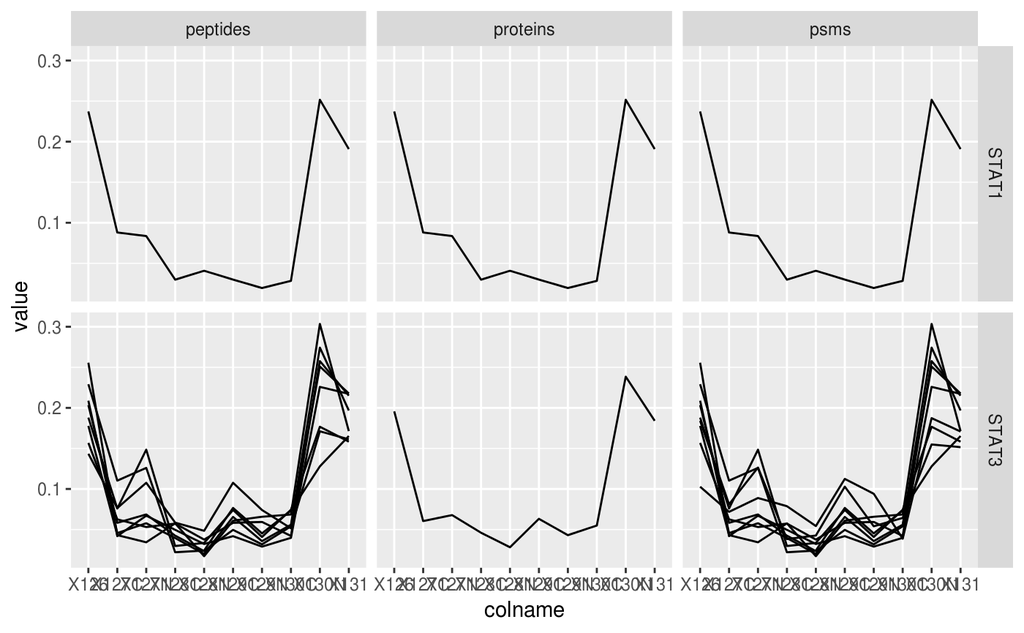

Figure 5: Examples of aggregations

```r
(cptac <- combineFeatures(cptac, fcol = "Proteins", method = "mean"))
```

```
## MSnSet (storageMode: lockedEnvironment)
## assayData: 1125 features, 6 samples
##   element names: exprs
## protocolData: none
## phenoData
##   sampleNames: 6A_7 6A_8 ... 6B_9 (6 total)
##   varLabels: group sample
##   varMetadata: labelDescription
## featureData
##   featureNames: P00918ups|CAH2_HUMAN_UPS
##     P01008ups|ANT3_HUMAN_UPS;CON__P41361 ... sp|Q99383|HRP1_YEAST
##     (1125 total)
##   fvarLabels: Proteins Potential.contaminant ... CV.6B_9 (11 total)
##   fvarMetadata: labelDescription
## experimentData: use 'experimentData(object)'
## Annotation:
## - - - Processing information - - -
## Subset [11466,6][11357,6] Fri Jul  5 09:26:04 2019
## Subset [11357,6][4051,6] Fri Jul  5 09:26:05 2019
## Removed features with more than 0 NAs: Fri Jul  5 09:26:05 2019
## Dropped featureData's levels Fri Jul  5 09:26:05 2019
## Log transformed (base 2) Fri Jul  5 09:26:05 2019
## Normalised (quantiles): Fri Jul  5 09:26:05 2019
## Combined 4051 features into 1125 using mean: Fri Jul  5 09:26:06 2019
##  MSnbase version: 2.10.1
```

**As you will see in the next section, there are much better aggregation function than the mean!**